# Lab 2

Parker Davis

2023-01-27

# Tasks

## Task 1

Working Directory:

```r
getwd()
```

```
## [1] "C:/RPACKAGES/FALL224753davi0607/MATH 4753 Labs/Lab2"
```

## Task 2

```r
#Using Dr. Stewart's way
directory="C:\\RPACKAGES\\FALL224753davi0607\\MATH 4753 Labs\\Lab2\\"


#The function to read data in by Dr. Stewart
myread=function(csv){
  fl=paste(directory,csv,sep="")
  read.table(fl,header=TRUE,sep=",")
}


#Assigning maybe in a simpler way to a variable
EPAGAS <- read.csv("EPAGAS.csv")
EPAGASalso <- myread("EPAGAS.csv")
head(EPAGAS, 6)
```

```
##    MPG
## 1 36.3
## 2 41.0
## 3 36.9
## 4 37.1
## 5 44.9
## 6 36.8
```

```r
head(EPAGASalso, 6)
```

```
##    MPG
## 1 36.3
## 2 41.0
## 3 36.9
## 4 37.1
## 5 44.9
## 6 36.8
```

```r
#Ok, so I have two of the same thing but I see how to do it both ways :).
```

## Task 3

```r
mpg = EPAGAS$MPG
z=(mpg-mean(mpg))/sd(mpg)
class(z)
```

```
## [1] "numeric"
```

```r
#Extremely small mean- approximately 0.
mean(z)
```

```
## [1] 1.058709e-16
```

```r
var(z)
```

```
## [1] 1
```

```r
#Possible Outliers (Zscores first then Actual Values)
z[abs(z)>=2&abs(z)<=3]
```

```
## [1] -2.892596  2.111752 -2.148148
```

```r
mpg[abs(z)>=2&abs(z)<=3]
```

```
## [1] 30.0 42.1 31.8
```

```r
#Defined Outliers (Zscores first then Actual Values)
z[abs(z)>3]
```

```
## [1] 3.269784
```

```r
mpg[abs(z)>3]
```

```
## [1] 44.9
```

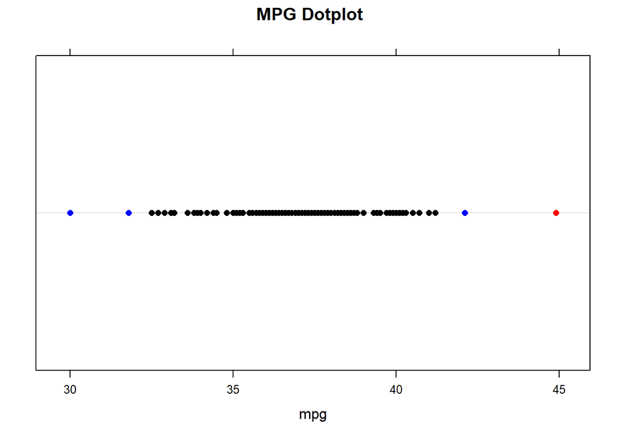

```r
#Creating the column color specifications
labcol= ifelse(abs(z) > 3, "Red", ifelse(abs(z)>=2 & abs(z)<=3, "Blue", "Black"))

#Dotplot of mpg data with OUTLIERS colored.
library(lattice)
dotplot(mpg, col = labcol, main = "MPG Dotplot")
```

## Task 4

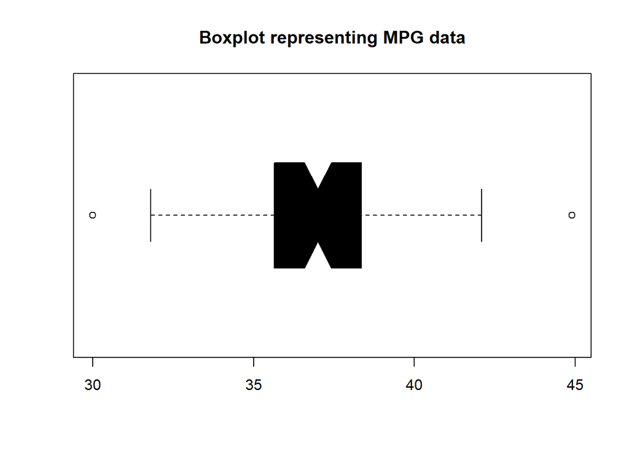

```r
#Boxplot for mpg
boxplot(mpg, col = "Black", notch = TRUE, main= "Boxplot representing MPG data",horizontal = TRUE)
```

Using Chebyshev’s Theorem, we woud predict the proportion of data within 2 sd of the mean to be (at least):

```r
1-(1/(2^2))
```

```
## [1] 0.75
```

The exact proportion within 2 sd of the mean is

```r
#This takes the 'length'/number of entries within 2 sd of the mean and divides by the actual length to create a proportion
length(mpg[abs(z)<2])/length(mpg)
```

```
## [1] 0.96
```

From this information, we can say that Chebyshev would agree with the data. This is because the theorem states that ‘at least’ 3/4 of the data will fall within 2 sd. While the actual proportion was closer to .96, that still is greater than 3/4, which Chebyshev predicts. Chebyshev’s proportion lays out the minimum proportion per amount of standard deviations, so if we had a proportion less than 3/4, then I would be concerned with the data.  
Using the Empirical Rule, approximately .95 is the proportion of the data that should be within 2 standard deviations. This corresponds very well, as the actual proportion of the data is .96.

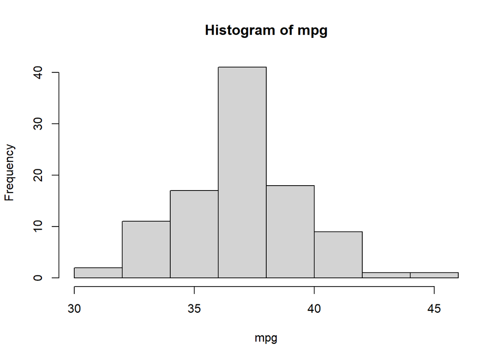

```r
#Verify Empirical Rule Applies
hist(mpg)
```

Thus, I would say that the Empirical Rule is valid, because the two assumptions we make were met:  
1. The dataset is UNIMODAL  
2. The dataset is (approximately) SYMMETRIC  
We can tell this from the boxplot and dotplot that we made.